# PfSPZ correlation chord diagrams: Delta (Post-vaccination- baseline)

# Rename the columns in the merged data at this point, since these names will be carried over to the final correlation matrix

```r
## For high-level BTMs:
all_data_btm<-all_data_btm %>%
  dplyr::rename("Outcome" = "tte.mal.atp.6") %>%
  dplyr::rename("PfSPZ stimulated CD4+ T cells" = "FACS_PfSPZ-specific_CD3+CD4+_of_live_lymphocytes")%>%
  dplyr::rename( "PfSPZ stimulated CD8+ T cells"= "FACS_PfSPZ-specific_CD3+CD8+_of_live_lymphocytes")%>%
  dplyr::rename("CD19+ B cells" = "FACS_CD19+_of_live_lymphocytes")%>%
  dplyr::rename("FACS Plasmablasts" = "FACS_Plasmablasts_of_live_lymphocytes")%>%
  dplyr::rename("CD11c+ monocytes" = "FACS_CD11c+_of_live_monocytes")%>%
  dplyr::rename("CD14+ monocytes" = "FACS_CD14+_of_live_monocytes")%>%
  dplyr::rename("CSP specific of memory B cells" = "FACS_CSP-spec_of_memory_B_cells")%>%
  dplyr::rename("IgG+ of CSP specific B cells" = "FACS_IgG_of_CSP-spec")%>%
  dplyr::rename("IgM+ of CSP specific B cells" = "FACS_IgM_of_CSP-spec")%>%
  dplyr::rename("IgG-IgM- of CSP specific B cells"= "FACS_IgG-IgM-_of_CSP-spec")%>%
  dplyr::rename("Atypical memory of B cells" = "FACS_atypical_memory_of_B_cells")%>%
  dplyr::rename("PfSPZ stimulated Vδ1 of T cells"  = "FACS_PfSPZ-specific_Vd1_of_T_cells")%>%
  dplyr::rename("PfSPZ stimulated Vδ1/2 of T cells"  = "FACS_PfSPZ-specific_Vd1/2-_of_T_cells")%>%
  dplyr::rename("PfSPZ stimulated Vδ9-Vδ2+ of T cells"  = "FACS_PfSPZ-specific_Vg9-Vd2+_of_T_cells")%>%
  dplyr::rename("PfSPZ stimulated Vδ9+Vδ2+ of T cells"  = "FACS_PfSPZ-specific_Vg9+Vd2+_of_T_cells")%>%
  dplyr::rename("CD14+CD16+ of monocytes"  = "FACS_CD14+CD16+_of_live_monocytes")%>%
  dplyr::rename("CD14+CD16- of monocytes"  = "FACS_CD14+CD16-_of_live_monocytes")%>%
  dplyr::rename("CD14-CD16+ of monocytes"  = "FACS_CD14-CD16+_of_live_monocytes")%>%
  dplyr::rename("Postvax anti-CSP IgG"  = "anti-CSP IgG")%>%
      dplyr::rename("ANTIGEN PRESENTATION"  = "ANTIGEN.PRESENTATION")%>%
      dplyr::rename("CELL CYCLE"  = "CELL.CYCLE")%>%
      dplyr::rename("DC ACTIVATION"  = "DC.ACTIVATION")%>%
      dplyr::rename("ECM AND MIGRATION"  = "ECM.AND.MIGRATION")%>%
      dplyr::rename("INFLAMMATORY/ TLR CHEMOKINES"  = "INFLAMMATORY.TLR.CHEMOKINES")%>%
  dplyr::rename("INTERFERON/ ANTIVIRAL SENSING"  = "INTERFERON.ANTIVIRAL.SENSING")%>%
  dplyr::rename("MONOCYTES"  = "MONOCYTES")%>%
    #dplyr::rename("NEUTROPHILS"  = "NEUTROPHILS")%>%
    dplyr::rename("NK CELLS"  = "NK.CELLS")%>%
    dplyr::rename("PLASMA CELLS"  = "PLASMA.CELLS")%>%
    dplyr::rename("SIGNAL TRANSDUCTION"  = "SIGNAL.TRANSDUCTION")%>%
     dplyr::rename("T CELLS"  = "T.CELLS")%>%
   dplyr::rename("B CELLS"  = "B.CELLS")


## For Monaco et al. modules:
all_data_monaco<-all_data_monaco %>%
  dplyr::rename("Outcome" = "tte.mal.atp.6") %>%
  dplyr::rename("PfSPZ stimulated CD4+ T cells" = "FACS_PfSPZ-specific_CD3+CD4+_of_live_lymphocytes")%>%
  dplyr::rename( "PfSPZ stimulated CD8+ T cells"= "FACS_PfSPZ-specific_CD3+CD8+_of_live_lymphocytes")%>%
  dplyr::rename("CD19+ B cells" = "FACS_CD19+_of_live_lymphocytes")%>%
  dplyr::rename("FACS Plasmablasts" = "FACS_Plasmablasts_of_live_lymphocytes")%>%
  dplyr::rename("CD11c+ monocytes" = "FACS_CD11c+_of_live_monocytes")%>%
  dplyr::rename("CD14+ monocytes" = "FACS_CD14+_of_live_monocytes")%>%
  dplyr::rename("CSP specific of memory B cells" = "FACS_CSP-spec_of_memory_B_cells")%>%
  dplyr::rename("IgG+ of CSP specific B cells" = "FACS_IgG_of_CSP-spec")%>%
  dplyr::rename("IgM+ of CSP specific B cells" = "FACS_IgM_of_CSP-spec")%>%
  dplyr::rename("IgG-IgM- of CSP specific B cells"= "FACS_IgG-IgM-_of_CSP-spec")%>%
  dplyr::rename("Atypical memory of B cells" = "FACS_atypical_memory_of_B_cells")%>%
  dplyr::rename("PfSPZ stimulated Vδ1 of T cells"  = "FACS_PfSPZ-specific_Vd1_of_T_cells")%>%
  dplyr::rename("PfSPZ stimulated Vδ1/2 of T cells"  = "FACS_PfSPZ-specific_Vd1/2-_of_T_cells")%>%
  dplyr::rename("PfSPZ stimulated Vδ9-Vδ2+ of T cells"  = "FACS_PfSPZ-specific_Vg9-Vd2+_of_T_cells")%>%
  dplyr::rename("PfSPZ stimulated Vδ9+Vδ2+ of T cells"  = "FACS_PfSPZ-specific_Vg9+Vd2+_of_T_cells")%>%
  dplyr::rename("CD14+CD16+ of monocytes"  = "FACS_CD14+CD16+_of_live_monocytes")%>%
  dplyr::rename("CD14+CD16- of monocytes"  = "FACS_CD14+CD16-_of_live_monocytes")%>%
  dplyr::rename("CD14-CD16+ of monocytes"  = "FACS_CD14-CD16+_of_live_monocytes")%>%
  dplyr::rename("Postvax anti-CSP IgG"  = "anti-CSP IgG")%>%
dplyr::rename("Memory B cells"  = "B.Memory")%>%
  dplyr::rename("Naive B cells"  = "B.Naive")%>%
  dplyr::rename("Basophils"  = "Basophils.LD")%>%
  dplyr::rename("MAIT T cells"  = "MAIT")%>%
  dplyr::rename("myeloid Dendritic cells"  = "mDCs")%>%
  dplyr::rename("Classical monocytes"  = "Monocytes.C")%>%
  dplyr::rename("Non-classical monocytes"  = "Monocytes.NC.I")%>%
  dplyr::rename("Neutrophils"  = "Neutrophils.LD")%>%
  dplyr::rename("NK cells"  = "NK")%>%
  dplyr::rename("plasmacytoid Dendritic cells"  = "pDCs")%>%
 dplyr::rename("Plasmablasts Monaco module"  = "Plasmablasts")%>%
  dplyr::rename("Memory CD4+ T cells"  = "T.CD4.Memory")%>%
    dplyr::rename("Naive CD4+ T cells"  = "T.CD4.Naive")%>%
    dplyr::rename("Memory CD8+ T cells"  = "T.CD8.Memory")%>%
    dplyr::rename("Naive CD8+ T cells"  = "T.CD8.Naive")%>%
    dplyr::rename("Non-Vδ2 γδ T cells"  = "T.gd.non.Vd2")%>%
    dplyr::rename("Vδ2 γδ T cells"  = "T.gd.Vd2")

#Clean up the merged table, removing columns that are not needed
all_data_btm<-all_data_btm[,-c(1:4)]
all_data_monaco<-all_data_monaco[,-c(1:4)]
```

#Run correlations

```r
## Create the corraltion matrix for BTMs
cor_btm<-cor(na.omit(all_data_btm), use = "pairwise.complete.obs")
# Create a p value matrix
p.mat_btm<-cor_pmat(na.omit(all_data_btm), use="pairwise.complete.obs")
# Convert p values to False Discovery Rates
p.mat_btm[]<-p.adjust(p.mat_btm, method = 'BH' )
p.mat_btm[lower.tri(p.mat_btm, diag=TRUE)] <- NA   #use adjusted P values
p.mat_btm <- pmax(p.mat_btm, t(p.mat_btm), na.rm=TRUE)

# use an FDR cutoff to include only significant correlations (cutoffs indicated in figure legends)
fdr <- 0.1
d_sig_btm  <- which(p.mat_btm <fdr, arr.ind = T)
foo_cor_btm <- cor_btm[unique(d_sig_btm[,1]),unique(d_sig_btm[,2])]  #get row and columns that include significant values
foo_pval_btm <- p.mat_btm[unique(d_sig_btm[,1]),unique(d_sig_btm[,2])]  #get row and columns that include significant values
foo_cor_btm[foo_pval_btm>=fdr] <- 0                                 #for cor values not signficant, make 0
foo_cor_btm[foo_cor_btm>0.999999] <- 0                                 #for cor values that are symmetric, make 0


## Create the corraltion matrix for Monaco modules
cor_m<-cor(na.omit(all_data_monaco), use = "pairwise.complete.obs")
# Create a p value matrix
p.mat_m<-cor_pmat(na.omit(all_data_monaco), use="pairwise.complete.obs")
# Convert p values to False Discovery Rates
p.mat_m[]<-p.adjust(p.mat_m, method = 'BH' )
p.mat_m[lower.tri(p.mat_m, diag=TRUE)] <- NA   #use adjusted P values
p.mat_m <- pmax(p.mat_m, t(p.mat_m), na.rm=TRUE)

# use an FDR cutoff to include only significant correlations (cutoffs indicated in figure legends)
fdr <- 0.2
d_sig_m  <- which(p.mat_m <fdr, arr.ind = T)
foo_cor_m <- cor_m[unique(d_sig_m[,1]),unique(d_sig_m[,2])] #get row and columns that include significant values
foo_pval_m <- p.mat_m[unique(d_sig_m[,1]),unique(d_sig_m[,2])]  #get row and columns that include significant values
foo_cor_m[foo_pval_m>=fdr] <- 0                                 #for cor values not signficant, make 0
foo_cor_m[foo_cor_m>0.999999] <- 0                                 #for cor values that are symmetric, make 0
```

# Set each row of the correlation matrix into a category (“Data.Type”). This will allow us to cluster and classify the correlations into the assigned categories when creating the chord diagram

```r
## For hi-level BTMs
combo3_btm<-as.data.frame(foo_cor_btm)
combo3_btm$Data.Type <- " "
combo3_btm$Data.Type <- ifelse(grepl("Outcome", rownames(combo3_btm)), "Outcome", combo3_btm$Data.Type)
combo3_btm$Data.Type <- ifelse(grepl("PfSPZ stimulated CD4\\+ T cells", rownames(combo3_btm)), "Cellular expression", combo3_btm$Data.Type)
combo3_btm$Data.Type <- ifelse(grepl("PfSPZ stimulated CD8\\+ T cells", rownames(combo3_btm)), "Cellular expression", combo3_btm$Data.Type)
combo3_btm$Data.Type <- ifelse(grepl("CD19\\+ B cells", rownames(combo3_btm)), "Cellular expression", combo3_btm$Data.Type)
combo3_btm$Data.Type <- ifelse(grepl("FACS Plasmablasts", rownames(combo3_btm)), "Cellular expression", combo3_btm$Data.Type)
combo3_btm$Data.Type <- ifelse(grepl("CD11c\\+ monocytes", rownames(combo3_btm)), "Cellular expression", combo3_btm$Data.Type)
combo3_btm$Data.Type <- ifelse(grepl("CD14\\+ monocytes", rownames(combo3_btm)), "Cellular expression", combo3_btm$Data.Type)
combo3_btm$Data.Type <- ifelse(grepl("CSP specific of memory B cells", rownames(combo3_btm)), "Cellular expression", combo3_btm$Data.Type)
combo3_btm$Data.Type <- ifelse(grepl("IgM\\+ of CSP specific B cells", rownames(combo3_btm)), "Cellular expression", combo3_btm$Data.Type)
combo3_btm$Data.Type <- ifelse(grepl("IgG\\+ of CSP specific B cells", rownames(combo3_btm)), "Cellular expression", combo3_btm$Data.Type)
combo3_btm$Data.Type <- ifelse(grepl("IgG\\-IgM\\- of CSP specific B cells", rownames(combo3_btm)), "Cellular expression", combo3_btm$Data.Type)
combo3_btm$Data.Type <- ifelse(grepl("Atypical memory of B cells", rownames(combo3_btm)), "Cellular expression", combo3_btm$Data.Type)
combo3_btm$Data.Type <- ifelse(grepl("PfSPZ stimulated Vδ1 of T cells", rownames(combo3_btm)), "Cellular expression", combo3_btm$Data.Type)
combo3_btm$Data.Type <- ifelse(grepl("PfSPZ stimulated Vδ1/2 of T cells", rownames(combo3_btm)), "Cellular expression", combo3_btm$Data.Type)
combo3_btm$Data.Type <- ifelse(grepl("PfSPZ stimulated Vδ9\\-Vδ2\\+ of T cells", rownames(combo3_btm)), "Cellular expression", combo3_btm$Data.Type)
combo3_btm$Data.Type <- ifelse(grepl("PfSPZ stimulated Vδ9\\+Vδ2\\+ of T cells", rownames(combo3_btm)), "Cellular expression", combo3_btm$Data.Type)
combo3_btm$Data.Type <- ifelse(grepl("CD14\\+CD16\\+ of monocytes", rownames(combo3_btm)), "Cellular expression", combo3_btm$Data.Type)
combo3_btm$Data.Type <- ifelse(grepl("CD14\\+CD16\\- of monocytes", rownames(combo3_btm)), "Cellular expression", combo3_btm$Data.Type)
combo3_btm$Data.Type <- ifelse(grepl("CD14\\-CD16\\+ of monocytes", rownames(combo3_btm)), "Cellular expression", combo3_btm$Data.Type)
combo3_btm$Data.Type <- ifelse(grepl("Postvax anti-CSP IgG", rownames(combo3_btm)), "Outcome", combo3_btm$Data.Type)
combo3_btm$Data.Type <- ifelse(grepl("ANTIGEN PRESENTATION", rownames(combo3_btm)), "Gene Expression", combo3_btm$Data.Type)
combo3_btm$Data.Type <- ifelse(grepl("B CELLS", rownames(combo3_btm)), "Gene Expression", combo3_btm$Data.Type)
combo3_btm$Data.Type <- ifelse(grepl("CELL CYCLE", rownames(combo3_btm)), "Gene Expression", combo3_btm$Data.Type)
combo3_btm$Data.Type <- ifelse(grepl("DC ACTIVATION", rownames(combo3_btm)), "Gene Expression", combo3_btm$Data.Type)
combo3_btm$Data.Type <- ifelse(grepl("ECM AND MIGRATION", rownames(combo3_btm)), "Gene Expression", combo3_btm$Data.Type)
combo3_btm$Data.Type <- ifelse(grepl("INFLAMMATORY/ TLR CHEMOKINES", rownames(combo3_btm)), "Gene Expression", combo3_btm$Data.Type)
combo3_btm$Data.Type <- ifelse(grepl("INTERFERON/ ANTIVIRAL SENSING", rownames(combo3_btm)), "Gene Expression", combo3_btm$Data.Type)
combo3_btm$Data.Type <- ifelse(grepl("MONOCYTES", rownames(combo3_btm)), "Gene Expression", combo3_btm$Data.Type)
combo3_btm$Data.Type <- ifelse(grepl("NEUTROPHILS", rownames(combo3_btm)), "Gene Expression", combo3_btm$Data.Type)
combo3_btm$Data.Type <- ifelse(grepl("NK CELLS", rownames(combo3_btm)), "Gene Expression", combo3_btm$Data.Type)
combo3_btm$Data.Type <- ifelse(grepl("PLASMA CELLS", rownames(combo3_btm)), "Gene Expression", combo3_btm$Data.Type)
combo3_btm$Data.Type <- ifelse(grepl("SIGNAL TRANSDUCTION", rownames(combo3_btm)), "Gene Expression", combo3_btm$Data.Type)
combo3_btm$Data.Type <- ifelse(grepl("T CELLS", rownames(combo3_btm)), "Gene Expression", combo3_btm$Data.Type)


## For Monaco modules
combo3_monaco<-as.data.frame(foo_cor_m)
combo3_monaco$Data.Type <- " "
combo3_monaco$Data.Type <- ifelse(grepl("Outcome", rownames(combo3_monaco)), "Outcome", combo3_monaco$Data.Type)
combo3_monaco$Data.Type <- ifelse(grepl("PfSPZ stimulated CD4\\+ T cells", rownames(combo3_monaco)), "Cellular expression", combo3_monaco$Data.Type)
combo3_monaco$Data.Type <- ifelse(grepl("PfSPZ stimulated CD8\\+ T cells", rownames(combo3_monaco)), "Cellular expression", combo3_monaco$Data.Type)
combo3_monaco$Data.Type <- ifelse(grepl("CD19\\+ B cells", rownames(combo3_monaco)), "Cellular expression", combo3_monaco$Data.Type)
combo3_monaco$Data.Type <- ifelse(grepl("FACS Plasmablasts", rownames(combo3_monaco)), "Cellular expression", combo3_monaco$Data.Type)
combo3_monaco$Data.Type <- ifelse(grepl("CD11c\\+ monocytes", rownames(combo3_monaco)), "Cellular expression", combo3_monaco$Data.Type)
combo3_monaco$Data.Type <- ifelse(grepl("CD14\\+ monocytes", rownames(combo3_monaco)), "Cellular expression", combo3_monaco$Data.Type)
combo3_monaco$Data.Type <- ifelse(grepl("CSP specific of memory B cells", rownames(combo3_monaco)), "Cellular expression", combo3_monaco$Data.Type)
combo3_monaco$Data.Type <- ifelse(grepl("IgM\\+ of CSP specific B cells", rownames(combo3_monaco)), "Cellular expression", combo3_monaco$Data.Type)
combo3_monaco$Data.Type <- ifelse(grepl("IgG\\+ of CSP specific B cells", rownames(combo3_monaco)), "Cellular expression", combo3_monaco$Data.Type)
combo3_monaco$Data.Type <- ifelse(grepl("IgG\\-IgM\\- of CSP specific B cells", rownames(combo3_monaco)), "Cellular expression", combo3_monaco$Data.Type)
combo3_monaco$Data.Type <- ifelse(grepl("Atypical memory of B cells", rownames(combo3_monaco)), "Cellular expression", combo3_monaco$Data.Type)
combo3_monaco$Data.Type <- ifelse(grepl("PfSPZ stimulated Vδ1 of T cells", rownames(combo3_monaco)), "Cellular expression", combo3_monaco$Data.Type)
combo3_monaco$Data.Type <- ifelse(grepl("PfSPZ stimulated Vδ1/2 of T cells", rownames(combo3_monaco)), "Cellular expression", combo3_monaco$Data.Type)
combo3_monaco$Data.Type <- ifelse(grepl("PfSPZ stimulated Vδ9\\-Vδ2\\+ of T cells", rownames(combo3_monaco)), "Cellular expression", combo3_monaco$Data.Type)
combo3_monaco$Data.Type <- ifelse(grepl("PfSPZ stimulated Vδ9\\+Vδ2\\+ of T cells", rownames(combo3_monaco)), "Cellular expression", combo3_monaco$Data.Type)
combo3_monaco$Data.Type <- ifelse(grepl("CD14\\+CD16\\+ of monocytes", rownames(combo3_monaco)), "Cellular expression", combo3_monaco$Data.Type)
combo3_monaco$Data.Type <- ifelse(grepl("CD14\\+CD16\\- of monocytes", rownames(combo3_monaco)), "Cellular expression", combo3_monaco$Data.Type)
combo3_monaco$Data.Type <- ifelse(grepl("CD14\\-CD16\\+ of monocytes", rownames(combo3_monaco)), "Cellular expression", combo3_monaco$Data.Type)
combo3_monaco$Data.Type <- ifelse(grepl("Postvax anti-CSP IgG", rownames(combo3_monaco)), "Outcome", combo3_monaco$Data.Type)
combo3_monaco$Data.Type <- ifelse(grepl("Memory B cells", rownames(combo3_monaco)), "Gene Expression", combo3_monaco$Data.Type)
combo3_monaco$Data.Type <- ifelse(grepl("Naive B cells", rownames(combo3_monaco)), "Gene Expression", combo3_monaco$Data.Type)
combo3_monaco$Data.Type <- ifelse(grepl("Basophils", rownames(combo3_monaco)), "Gene Expression", combo3_monaco$Data.Type)
combo3_monaco$Data.Type <- ifelse(grepl("MAIT T cells", rownames(combo3_monaco)), "Gene Expression", combo3_monaco$Data.Type)
combo3_monaco$Data.Type <- ifelse(grepl("myeloid Dendritic cells", rownames(combo3_monaco)), "Gene Expression", combo3_monaco$Data.Type)
combo3_monaco$Data.Type <- ifelse(grepl("Classical monocytes", rownames(combo3_monaco)), "Gene Expression", combo3_monaco$Data.Type)
combo3_monaco$Data.Type <- ifelse(grepl("Non-classical monocytes", rownames(combo3_monaco)), "Gene Expression", combo3_monaco$Data.Type)
combo3_monaco$Data.Type <- ifelse(grepl("Neutrophils", rownames(combo3_monaco)), "Gene Expression", combo3_monaco$Data.Type)
combo3_monaco$Data.Type <- ifelse(grepl("NK cells", rownames(combo3_monaco)), "Gene Expression", combo3_monaco$Data.Type)
combo3_monaco$Data.Type <- ifelse(grepl("plasmacytoid Dendritic cells", rownames(combo3_monaco)), "Gene Expression", combo3_monaco$Data.Type)
combo3_monaco$Data.Type <- ifelse(grepl("Plasmablasts Monaco module", rownames(combo3_monaco)), "Gene Expression", combo3_monaco$Data.Type)
combo3_monaco$Data.Type <- ifelse(grepl("Memory CD4\\+ T cells", rownames(combo3_monaco)), "Gene Expression", combo3_monaco$Data.Type)
combo3_monaco$Data.Type <- ifelse(grepl("Naive CD4\\+ T cells", rownames(combo3_monaco)), "Gene Expression", combo3_monaco$Data.Type)
combo3_monaco$Data.Type <- ifelse(grepl("Memory CD8\\+ T cells", rownames(combo3_monaco)), "Gene Expression", combo3_monaco$Data.Type)
combo3_monaco$Data.Type <- ifelse(grepl("Naive CD8\\+ T cells", rownames(combo3_monaco)), "Gene Expression", combo3_monaco$Data.Type)
combo3_monaco$Data.Type <- ifelse(grepl("Non-Vδ2 γδ T cells", rownames(combo3_monaco)), "Gene Expression", combo3_monaco$Data.Type)
combo3_monaco$Data.Type <- ifelse(grepl("Vδ2 γδ T cells", rownames(combo3_monaco)), "Gene Expression", combo3_monaco$Data.Type)
```

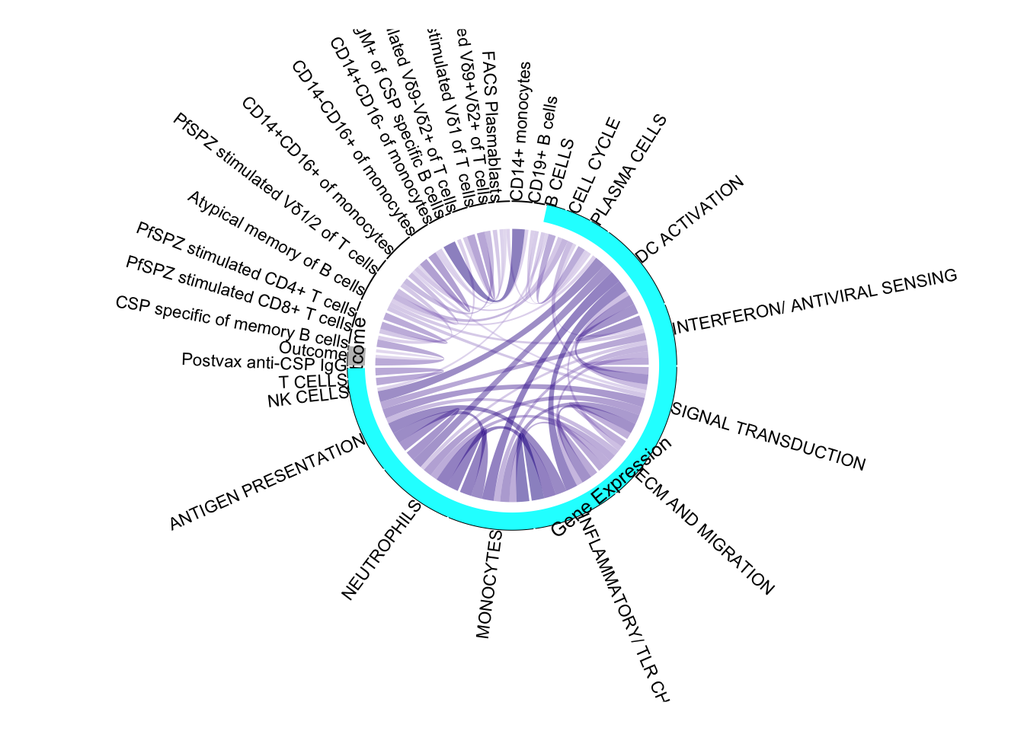

```r
palette(brewer.pal(12, "Set3"))

# Chord diagram for BTMs
set.seed(12)
df1_btm <- data.frame(variable = as.character(rownames(combo3_btm)), Group1 = combo3_btm$Data.Type)
gl1_btm <- split(df1_btm$variable, df1_btm$Group1, drop = FALSE)
gl1_btm <- sapply(gl1_btm, as.character)
group_color1_btm <- structure(circlize::rand_color(length(gl1_btm),hue = "monochrome", transparency = 0.5, luminosity = "dark"), names = names(gl1_btm))
n_group1_btm <-  length(gl1_btm)

## to get CSP-specific IgG, outcome and dose together
combo3_btm<-combo3_btm %>% arrange(factor(Data.Type, levels = c("Outcome", "Antibody","Cellular expression", "Gene Expression")))

combo4_btm <- combo3_btm[,intersect(rownames(combo3_btm), colnames(combo3_btm))]

#keep only the top triangle of the matrix, otherwise each correlation shows up twice on the diagram
combo4_btm[upper.tri(combo4_btm)] <- 0
combo4_btm[combo4_btm<0] <- 0
combo4_btm[combo4_btm == 0] <- NA

mat_btm <- as.matrix(combo4_btm)
order_btm<-colnames(mat_btm)
col_fun_btm <- colorRamp2(c( 0, 1), c( "white", "darkblue"), transparency = 0.5)


cairo_pdf("Timpoint_delta_FDR_0.1_Hilevel_BTMS.pdf", height = 10, width = 10)
circos.par(canvas.xlim = c(-1.8,1.8), canvas.ylim = c(-1.8,1.8), points.overflow.warning=FALSE,
           track.margin = c(0.01, 0.05), # adjust bottom and top margin
           track.height = 0.05, start.degree = 180)
chordDiagram(mat_btm, order=order_btm, col = col_fun_btm(mat_btm), annotationTrack = NULL, link.largest.ontop = TRUE, preAllocateTracks = list(track.height = 0.1), transparency = 0.25, self.link = 1)
circos.trackPlotRegion(track.index = 1, panel.fun = function(x, y) {
  xlim = get.cell.meta.data("xlim")
  ylim = get.cell.meta.data("ylim")
  sector.name = get.cell.meta.data("sector.index")
  circos.text(mean(xlim), ylim[1] + 1, sector.name, facing = "clockwise", niceFacing = TRUE, adj = c(0, 0), cex = 0.7) #text for parameters
  circos.axis(h = "top", labels.cex = 0.3, major.tick = FALSE, sector.index = sector.name, track.index = 1, labels = FALSE)
}, bg.border = NA)
highlight.sector(rownames(combo3_btm)[which(combo3_btm$Data.Type == "Outcome")],
                 track.index = get.all.track.index(), col = "grey",
                 text = "Outcome", cex = 0.8, text.col = "black", niceFacing = TRUE)
# Gene expression
highlight.sector(rownames(combo3_btm)[which(combo3_btm$Data.Type == "Gene Expression")],
                 track.index = get.all.track.index(), col = "cyan",
                 text = "Gene Expression", cex = 0.8, text.col = "black", niceFacing = TRUE)
```

```r
# Cellular Expression
#highlight.sector(rownames(combo3_btm)[which(combo3_btm$Data.Type == "Cellular expression")],
#                 track.index = get.all.track.index(), col = "blue",
#                 text = "Cellular Expression", cex = 0.8, text.col = "pink", niceFacing = TRUE)
dev.off()
```

```r
circos.clear()
```

#Plot the chord diagram for Monaco modules

```r
palette(brewer.pal(12, "Set3"))
set.seed(12)
df1_monaco <- data.frame(variable = as.character(rownames(combo3_monaco)), Group1 = combo3_monaco$Data.Type)
gl1_monaco <- split(df1_monaco$variable, df1_monaco$Group1, drop = FALSE)
gl1_monaco <- sapply(gl1_monaco, as.character)
group_color1_monaco <- structure(circlize::rand_color(length(gl1_monaco),hue = "monochrome", transparency = 0.5, luminosity = "dark"), names = names(gl1_monaco))
n_group1_monaco <-  length(gl1_monaco)

## to get CSP-specific IgG, outcome and dose together
combo3_monaco<-combo3_monaco %>% arrange(factor(Data.Type, levels = c("Outcome", "Antibody","Cellular expression",  "Gene Expression")))

combo4_monaco <- combo3_monaco[,intersect(rownames(combo3_monaco), colnames(combo3_monaco))]

#keep only the top triangle of the matrix, otherwise each correlation shows up twice on the diagram
combo4_monaco[upper.tri(combo4_monaco)] <- 0
combo4_monaco[combo4_monaco<0] <- 0
combo4_monaco[combo4_monaco == 0] <- NA

mat_monaco <- as.matrix(combo4_monaco)
order_monaco<-colnames(mat_monaco)
col_fun_monaco <- colorRamp2(c( 0, 1), c( "white", "darkblue"), transparency = 0.5)


cairo_pdf("Timpoint_delta_FDR_0.2_Monaco.pdf", height = 10, width = 10)
```

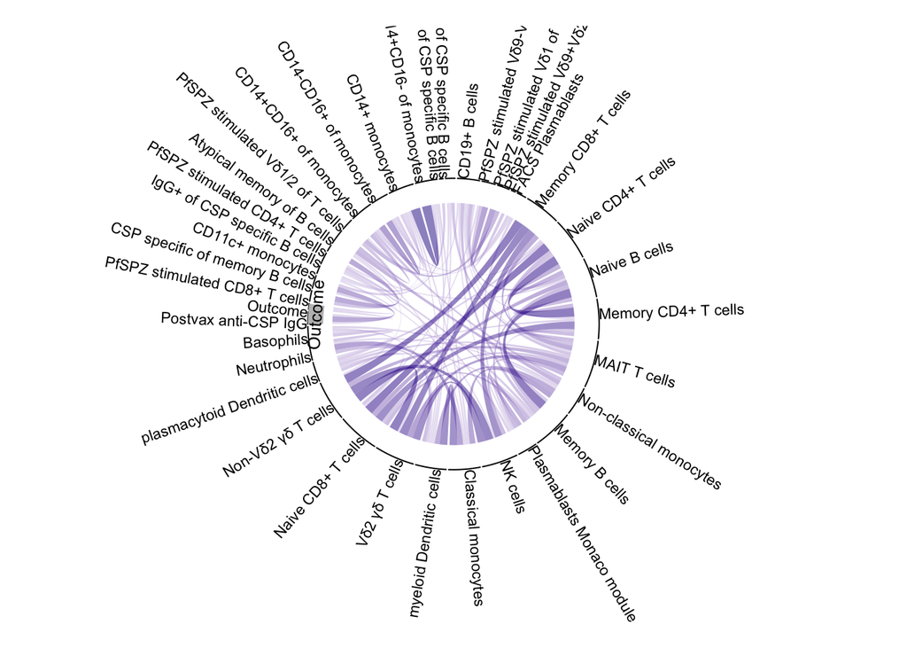

```r
circos.par(canvas.xlim = c(-1.8,1.8), canvas.ylim = c(-1.8,1.8), points.overflow.warning=FALSE,
           track.margin = c(0.01, 0.05), # adjust bottom and top margin
           track.height = 0.05, start.degree = 180)
chordDiagram(mat_monaco, order=order_monaco, col = col_fun_monaco(mat_monaco), annotationTrack = NULL, link.largest.ontop = TRUE, preAllocateTracks = list(track.height = 0.1), transparency = 0.25, self.link = 1)
circos.trackPlotRegion(track.index = 1, panel.fun = function(x, y) {
  xlim = get.cell.meta.data("xlim")
  ylim = get.cell.meta.data("ylim")
  sector.name = get.cell.meta.data("sector.index")
  circos.text(mean(xlim), ylim[1] + 1, sector.name, facing = "clockwise", niceFacing = TRUE, adj = c(0, 0), cex = 0.7) #text for parameters
  circos.axis(h = "top", labels.cex = 0.3, major.tick = FALSE, sector.index = sector.name, track.index = 1, labels = FALSE)
}, bg.border = NA)
highlight.sector(rownames(combo3_monaco)[which(combo3_monaco$Data.Type == "Outcome")],
                 track.index = get.all.track.index(), col = "grey",
                 text = "Outcome", cex = 0.8, text.col = "black", niceFacing = TRUE)
```

```r
dev.off()
```

```r
circos.clear()
```